# PRÁCTICA 2: COLGATE VS CREST

Predicción de series temporales

Guillermo González Díaz

14/11/2021

### **Conclusiones extraídas del trabajo:**

- Los modelos AUTOARIMA se comportan bien con las series temporales estudiadas.
- Nuestras series temporales tienen tendencia, estacionariedad y no presentan estacionalidad.
- Hemos visto el poder que puede tener sobre el mercado los comunicaciones realizadas por organismos oficiales
- Después de hallar la función de transferencia, los valores predictivos son mucho más acertados.

# *Gráficos de nuestras series temporales*

Podemos observar varias cosas en estos gráficos. En primer lugar, ambas series tienen tendencia. Crest creciente y Colgate decreciente. Podemos ver que a partir de 1960, Crest supera en cuota de mercado a Colgate para mantenerse de ese modo. En cuanto a la estacionalidad, no observamos ninguna, ya que al tratarse de dentífricos sabemos que no son porductos que presenten estacionalidad.

La explicación, es el informe publicado por el Consejo de Terapéutica Dental de la American Dental Association (ADA), resaltando los benificios de esta marca frente a otras. Así, vemos como en el período seleccionado, Colgate pasó en solamente 5 años de una cuota de mercado del 40 % al 20 %, en beneficio de Crest, una marca nueva que en solo 5 años alcanzó máximos del 50 %.

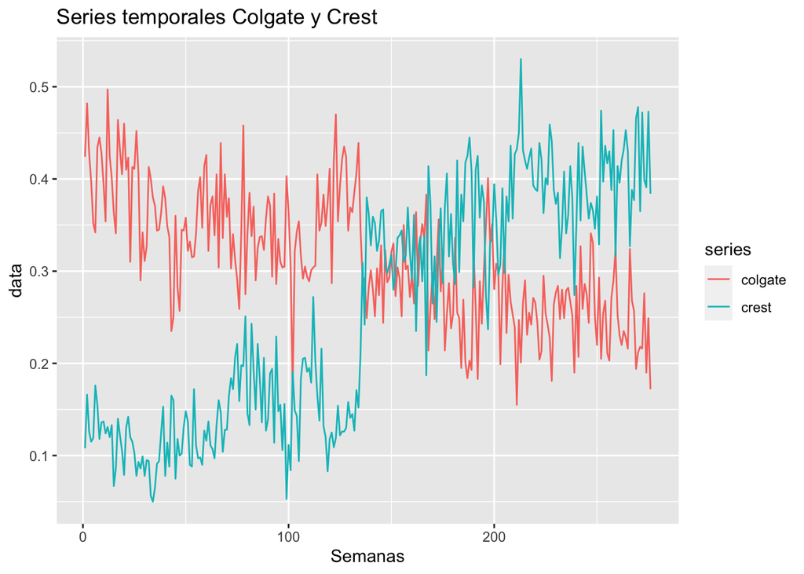

# *Train y Test*

Hemos dividido la muestra en train y test, pues uno de los objetivos del trabajo es predecir las últimas 16 semanas del período utilizando para ello modelos ARIMA. Así queda partida la muestra:

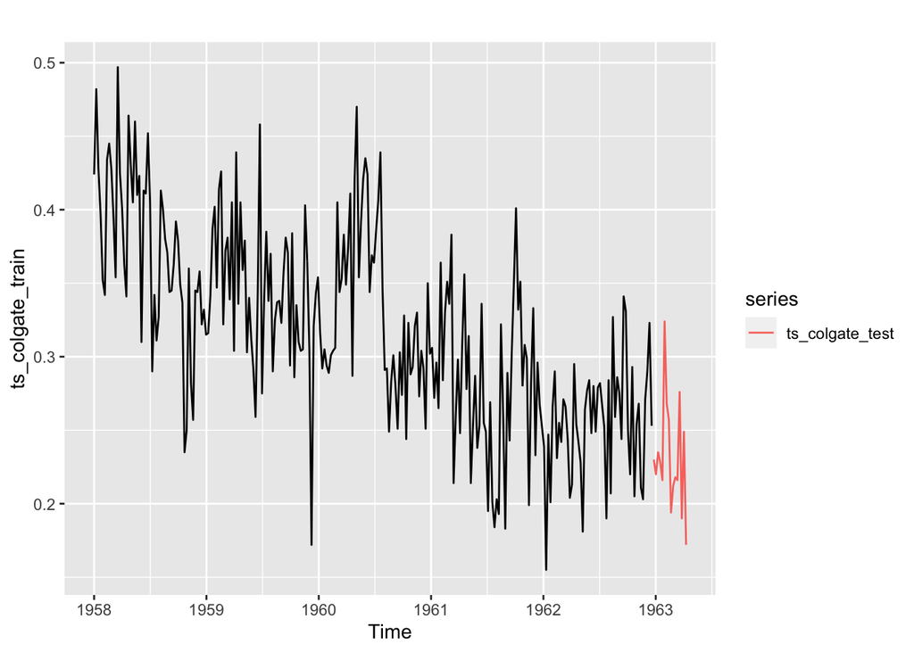

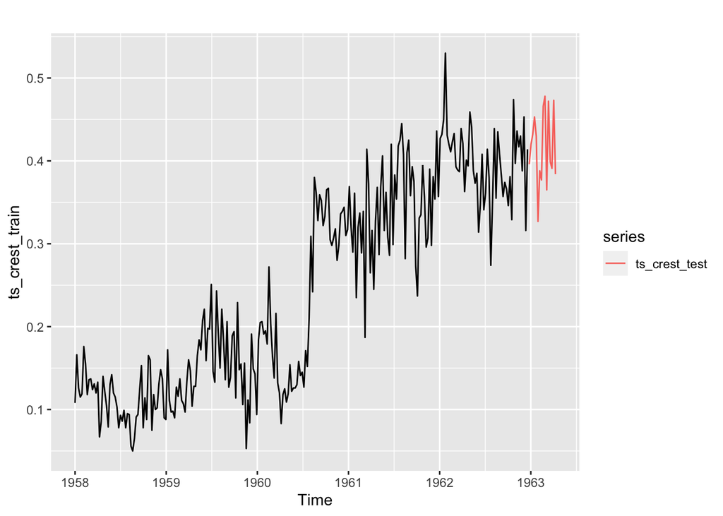

# *Autorima Colgate y predicción 16 períodos*

En primer lugar realizamos un autoarima con las dos series. Representamos gráficamete los residuos (en este caso solamente los de Colgate, teniendo en cuenta que los de Crest se comportan de manera muy similar), donde podemos comprobar que se comportan como ruido blanco: la media es constante en torno a 0. Por ello podemos decir que los modelos se ajustan bien y podemos predecir con ellos.

Estos son los resultados de las predicciones, en azul los intervalos de confianza al 95 %:

Análisis de los residuos de Colgate:

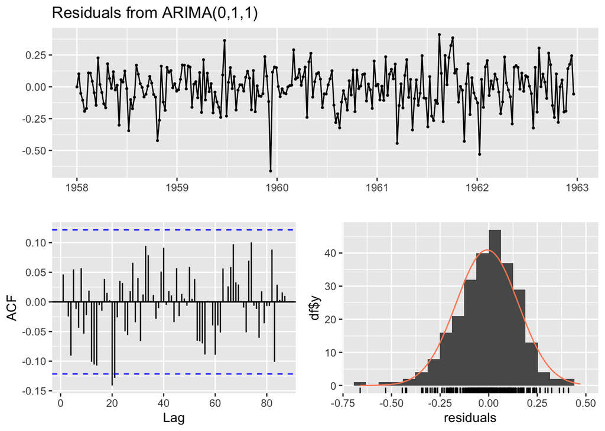

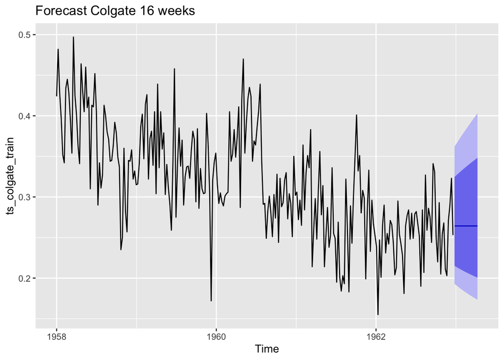

# *Autorima Crest y predicción 16 períodos*

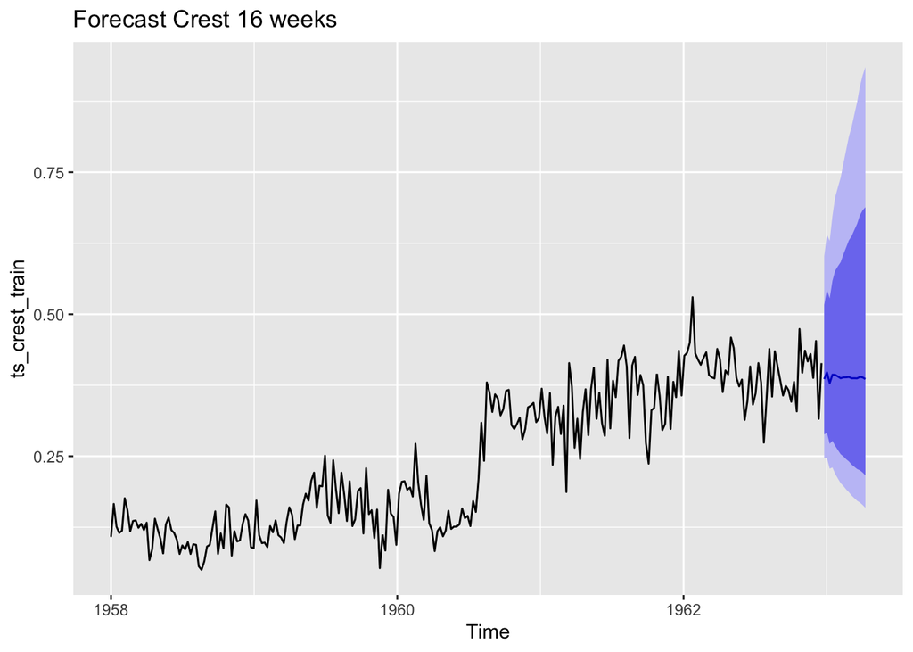

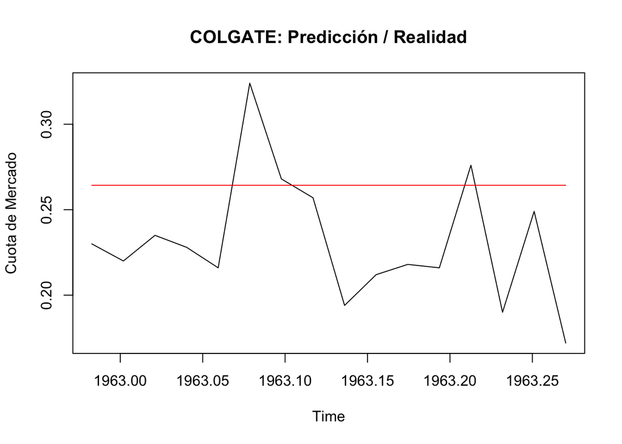

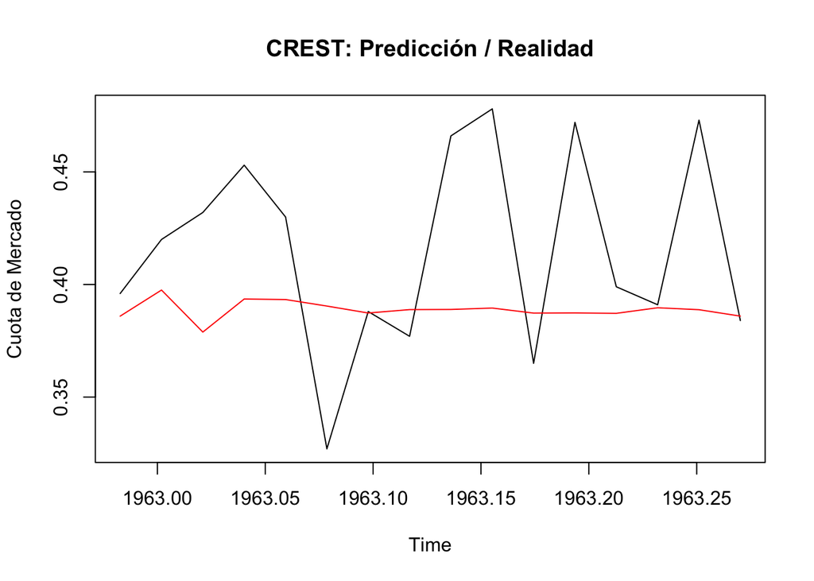

# *Valores atípicos*

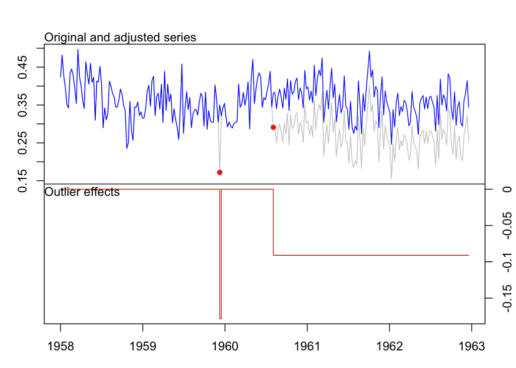

Crest: Aquí hemos encontrado 3 atípicos. Uno en la semana 32 de 1960, que tiene el efecto contrario al mismo de Colgate. Otro en la semana 11 de 1961, que vemos que es puntual ya que se recupera rápidamente. Por último, observamos uno en la semana 40 de 1961, donde la cuota car pero se va recuperando poco a poco.

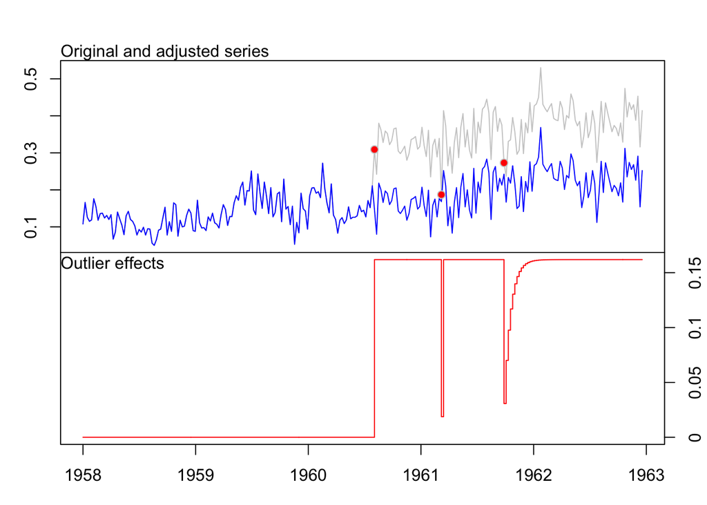

Llegados a este punto, podemos confirmar la fuerza que tuvo y el gran impacto para la cuota de mercado de ambas marcas, la aprobación de Crest como “Categoría B” por la ADA, confirmando la efectividad del dentífrico ante las caries dentales.

Crest se mantendrá como rey del sector hasta los años 90.

# *Modelos de intervención*

En el punto anterior nos hemos enconrtado con valores atípicos en ambos casos. Como se trata de series temporales, no podemos limitarnos a eliminarlos. Una serie temporal es continua y no podemos crear discontinuidades quitando datos. Queremos ver el impacto que tienen sobre la serie de datos, y principalmente son modelos que se realizan con ARIMA.

Estos valores tiene sus causas en el mercado y las estrategias de publicidad, y tienen su efecto en la tendencia de las series.

A continuación representamos los coeficientes de nuestro modelo de intervención sobre ambas series temporales, y después pasamos a analizar un outlier en concreto, el de agosto de 1960 y el efecto tan inmediato que tuvo en Crest.

Modelo de intervención de colgate:

```
##
## Call:
## arimax(x = int_data_col, order = c(3, 0, 0), seasonal = list(order = c(1, 0,
##     0), period = 52), xreg = dummies_colg, method = "ML")
##
## Coefficients:
##          ar1     ar2     ar3    sar1  intercept   AO1102   LS1136
##       0.2377  0.1615  0.1522  0.0307     0.3629  -0.1783  -0.0911
## s.e.  0.0619  0.0628  0.0626  0.0712     0.0087   0.0435   0.0122
##
## sigma^2 estimated as 0.002052:  log likelihood = 435.5,  aic = -857
```

Modelo de intervención de Crest:

```
##
## Call:
## arimax(x = int_data_crest, order = c(3, 1, 0), seasonal = list(order = c(1,
##     0, 0), period = 52), xreg = dummies_crest, method = "ML")
##
## Coefficients:
##           ar1      ar2      ar3    sar1  LS1136   AO1167   TC1196
##       -0.6991  -0.4515  -0.1914  0.0650  0.1374  -0.1349  -0.0992
## s.e.   0.0621   0.0710   0.0623  0.0672  0.0323   0.0384   0.0320
##
## sigma^2 estimated as 0.001768:  log likelihood = 452.81,  aic = -891.63
```

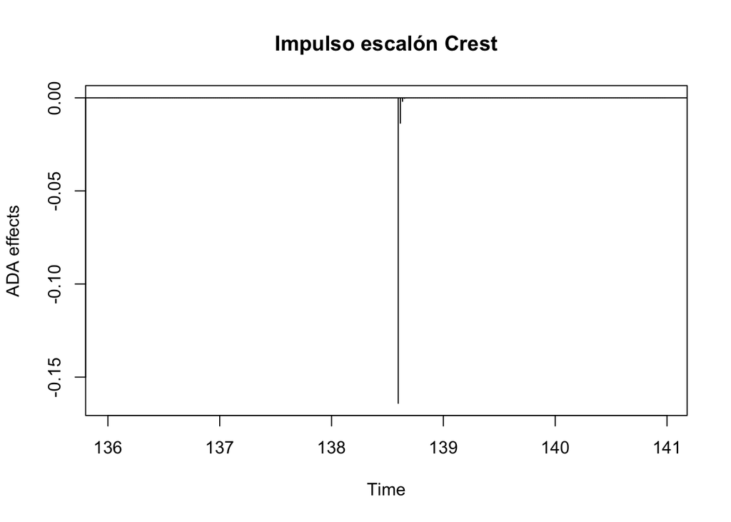

# *Función de transferencia*

Por último. Para ello hemos modelizado con Arima, hemos comprobado el número de coeficientes. Despúes con el análisis visual de los coeficientes sacamos b, r y s. Con todo ello realizamos un nuevo modelo Arimax, que usaremos para predecir las últimas 16 semanas de nuestra serie tempral. Aquí tenemos el resultado, una predicción bastante más ajustada que antes.

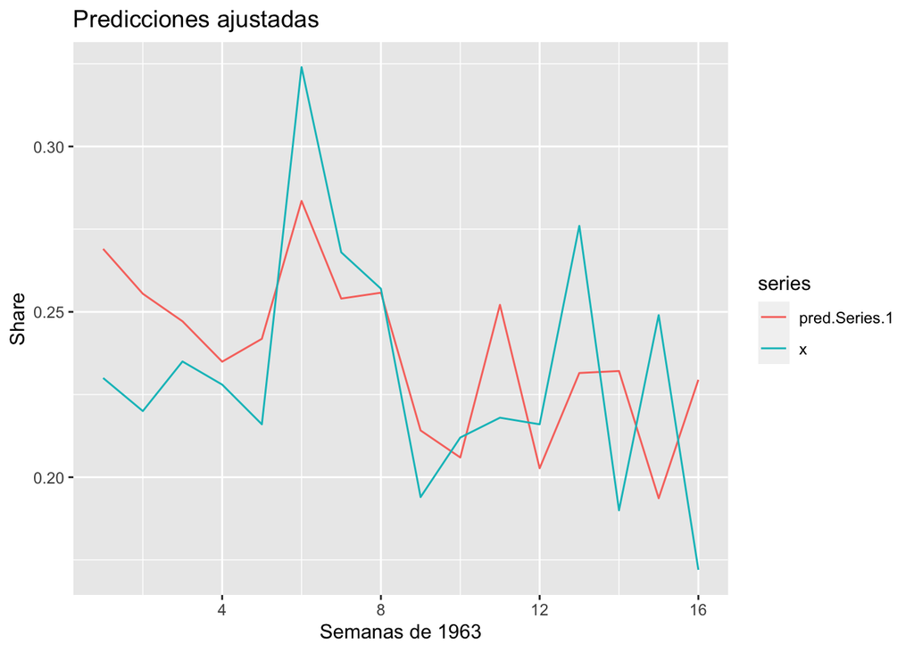